# Intro to Programming - Investigate a Dataset

To complete the project i chose the Gapminder-World-Dataset. Since global warming is a major topic of our time, i focused on this topic as an overarching theme, and took a deeper look at the C02 - dataset regarding the following questions:

- Which country has the highest C02-emission, compared to the population since 1945?
- Is there a correlation between population growth and C02-emission growth?
- Is there a correlation between higher gas prices and lower C02 emission?

```python
import pandas as pd
import numpy as np
import matplotlib.pyplot as plt
%matplotlib inline
```

## Data acquisition

This section shows, which .csv-files i used from https://www.gapminder.org/data/.

### CO2-emissions per person

First i downloaded the co2_emissions_tonnes_per_person.csv and used pandas to load it as a DataFrame.

```python
df_co2_emissions_tonnes_per_person=pd.read_csv('C:\Users\Moritz Stabel\Desktop\Projekt Udacity\data\co2_emissions_tonnes_per_person.csv',index_col=0)
```

This DataFrame contains de CO2-emission in tonnes per person for each country since the year 1800.

```python
df_co2_emissions_tonnes_per_person.head()
```

| country | 1800 | 1801 | 1802 | 1803 | 1804 | 1805 | 1806 | 1807 | 1808 | 1809 | ... | 2005 | 2006 | 2007 | 2008 | 2009 | 2010 | 2011 | 2012 | 2013 | 2014 |
| --- | --- | --- | --- | --- | --- | --- | --- | --- | --- | --- | --- | --- | --- | --- | --- | --- | --- | --- | --- | --- | --- |
| Afghanistan | NaN | NaN | NaN | NaN | NaN | NaN | NaN | NaN | NaN | NaN | ... | 0.0529 | 0.0637 | 0.0854 | 0.154 | 0.242 | 0.294 | 0.412 | 0.35 | 0.316 | 0.299 |
| Albania | NaN | NaN | NaN | NaN | NaN | NaN | NaN | NaN | NaN | NaN | ... | 1.3800 | 1.2800 | 1.3000 | 1.460 | 1.480 | 1.560 | 1.790 | 1.68 | 1.730 | 1.960 |
| Algeria | NaN | NaN | NaN | NaN | NaN | NaN | NaN | NaN | NaN | NaN | ... | 3.2200 | 2.9900 | 3.1900 | 3.160 | 3.420 | 3.300 | 3.290 | 3.46 | 3.510 | 3.720 |
| Andorra | NaN | NaN | NaN | NaN | NaN | NaN | NaN | NaN | NaN | NaN | ... | 7.3000 | 6.7500 | 6.5200 | 6.430 | 6.120 | 6.120 | 5.870 | 5.92 | 5.900 | 5.830 |
| Angola | NaN | NaN | NaN | NaN | NaN | NaN | NaN | NaN | NaN | NaN | ... | 0.9800 | 1.1000 | 1.2000 | 1.180 | 1.230 | 1.240 | 1.250 | 1.33 | 1.250 | 1.290 |

5 rows × 215 columns

### Total yearly CO2-emission in 1000 tonnes

Same happend with the yearly_co2_emission_1000_tonnes.csv.

```python
df_co2_emissions_yearly_1000_tonnes=pd.read_csv('C:\Users\Moritz Stabel\Desktop\Projekt Udacity\data\yearly_co2_emissions_1000_tonnes.csv',index_col=0)
```

This Dataframe contrains the yearly CO2-emission of each country in 1000 tonnes.

```python
df_co2_emissions_yearly_1000_tonnes.head()
```

| country | 1751 | 1752 | 1753 | 1754 | 1755 | 1756 | 1757 | 1758 | 1759 | 1760 | ... | 2005 | 2006 | 2007 | 2008 | 2009 | 2010 | 2011 | 2012 | 2013 | 2014 |
| --- | --- | --- | --- | --- | --- | --- | --- | --- | --- | --- | --- | --- | --- | --- | --- | --- | --- | --- | --- | --- | --- |
| Afghanistan | NaN | NaN | NaN | NaN | NaN | NaN | NaN | NaN | NaN | NaN | ... | 1330.0 | 1650.0 | 2270.0 | 4210.0 | 6770.0 | 8460.0 | 12200.0 | 10800.0 | 10000.0 | 9810.0 |
| Albania | NaN | NaN | NaN | NaN | NaN | NaN | NaN | NaN | NaN | NaN | ... | 4250.0 | 3900.0 | 3930.0 | 4370.0 | 4380.0 | 4600.0 | 5240.0 | 4910.0 | 5060.0 | 5720.0 |
| Algeria | NaN | NaN | NaN | NaN | NaN | NaN | NaN | NaN | NaN | NaN | ... | 107000.0 | 101000.0 | 109000.0 | 110000.0 | 121000.0 | 119000.0 | 121000.0 | 130000.0 | 134000.0 | 145000.0 |
| Andorra | NaN | NaN | NaN | NaN | NaN | NaN | NaN | NaN | NaN | NaN | ... | 576.0 | 546.0 | 539.0 | 539.0 | 517.0 | 517.0 | 491.0 | 488.0 | 477.0 | 462.0 |
| Angola | NaN | NaN | NaN | NaN | NaN | NaN | NaN | NaN | NaN | NaN | ... | 19200.0 | 22300.0 | 25200.0 | 25700.0 | 27800.0 | 29100.0 | 30300.0 | 33400.0 | 32600.0 | 34800.0 |

5 rows × 264 columns

### Total population

Same happend with the population_total.csv.

```python
df_population_total=pd.read_csv('C:\Users\Moritz Stabel\Desktop\Projekt Udacity\data\population_total.csv',index_col=0)
```

This DataFrame contains the population of each country.

```python
df_population_total.head()
```

| country | 1800 | 1801 | 1802 | 1803 | 1804 | 1805 | 1806 | 1807 | 1808 | 1809 | ... | 2009 | 2010 | 2011 | 2012 | 2013 | 2014 | 2015 | 2016 | 2017 | 2018 |
| --- | --- | --- | --- | --- | --- | --- | --- | --- | --- | --- | --- | --- | --- | --- | --- | --- | --- | --- | --- | --- | --- |
| Afghanistan | 3280000 | 3280000 | 3280000 | 3280000 | 3280000 | 3280000 | 3280000 | 3280000 | 3280000 | 3280000 | ... | 28000000 | 28800000 | 29700000 | 30700000 | 31700000 | 32800000 | 33700000 | 34700000 | 35500000 | 36400000 |
| Albania | 410000 | 412000 | 413000 | 414000 | 416000 | 417000 | 418000 | 420000 | 421000 | 422000 | ... | 2960000 | 2940000 | 2930000 | 2920000 | 2920000 | 2920000 | 2920000 | 2930000 | 2930000 | 2930000 |
| Algeria | 2500000 | 2510000 | 2520000 | 2530000 | 2540000 | 2550000 | 2560000 | 2570000 | 2580000 | 2590000 | ... | 35500000 | 36100000 | 36800000 | 37600000 | 38300000 | 39100000 | 39900000 | 40600000 | 41300000 | 42000000 |
| Andorra | 2650 | 2650 | 2650 | 2650 | 2650 | 2650 | 2650 | 2650 | 2650 | 2650 | ... | 84500 | 84400 | 83800 | 82400 | 80800 | 79200 | 78000 | 77300 | 77000 | 77000 |
| Angola | 1570000 | 1570000 | 1570000 | 1570000 | 1570000 | 1570000 | 1570000 | 1570000 | 1570000 | 1570000 | ... | 22500000 | 23400000 | 24200000 | 25100000 | 26000000 | 26900000 | 27900000 | 28800000 | 29800000 | 30800000 |

5 rows × 219 columns

### Gas price per liter

Same happend with the pump_price_for_gasoline_us_per_liter.csv.

```python
df_pump_price_for_gasoline_us_per_liter=pd.read_csv('C:\Users\Moritz Stabel\Desktop\Projekt Udacity\data\pump_price_for_gasoline_us_per_liter.csv',index_col=0)
```

This DataFrame contains the gas price per liter for each country. The local currencies were converted into US-Dollar.

```python
df_pump_price_for_gasoline_us_per_liter.head()
```

| country | 1991 | 1992 | 1993 | 1994 | 1995 | 1996 | 1997 | 1998 | 1999 | 2000 | ... | 2007 | 2008 | 2009 | 2010 | 2011 | 2012 | 2013 | 2014 | 2015 | 2016 |
| --- | --- | --- | --- | --- | --- | --- | --- | --- | --- | --- | --- | --- | --- | --- | --- | --- | --- | --- | --- | --- | --- |
| Afghanistan | NaN | NaN | NaN | NaN | NaN | NaN | NaN | NaN | NaN | NaN | ... | NaN | 1.05 | NaN | 1.15 | NaN | 1.28 | NaN | 1.07 | NaN | 0.70 |
| Albania | NaN | NaN | NaN | NaN | NaN | NaN | NaN | 0.86 | NaN | 0.57 | ... | NaN | 1.36 | NaN | 1.46 | NaN | 1.81 | NaN | 1.76 | NaN | 1.36 |
| Algeria | 0.15 | 0.2 | NaN | NaN | 0.4 | NaN | NaN | 0.31 | NaN | 0.27 | ... | NaN | 0.34 | NaN | 0.32 | NaN | 0.29 | NaN | 0.27 | NaN | 0.28 |
| Andorra | NaN | NaN | NaN | NaN | NaN | NaN | NaN | NaN | NaN | NaN | ... | NaN | 1.24 | NaN | 1.49 | NaN | 1.67 | NaN | 1.51 | NaN | NaN |
| Angola | NaN | NaN | NaN | NaN | NaN | NaN | NaN | 0.38 | NaN | 0.30 | ... | NaN | 0.53 | NaN | 0.65 | NaN | 0.63 | NaN | 0.76 | NaN | 0.97 |

5 rows × 26 columns

## Which country has the highest total C02-emission, compared to the population since 1945?

During this investigation im going to focus on the G20-countries, Since the data is complete for these countries and the result is therefore compareable.

The transpose function is used to swap years and countries in the DataFrame, so the plotting process would be easier.

```python
df_co2_emissions_tonnes_per_person_transposed=df_co2_emissions_tonnes_per_person.transpose()
```

```python
df_co2_emissions_tonnes_per_person_transposed.head()
```

| country | Afghanistan | Albania | Algeria | Andorra | Angola | Antigua and Barbuda | Argentina | Armenia | Australia | Austria | ... | United Kingdom | United States | Uruguay | Uzbekistan | Vanuatu | Venezuela | Vietnam | Yemen | Zambia | Zimbabwe |
| --- | --- | --- | --- | --- | --- | --- | --- | --- | --- | --- | --- | --- | --- | --- | --- | --- | --- | --- | --- | --- | --- |
| 1800 | NaN | NaN | NaN | NaN | NaN | NaN | NaN | NaN | NaN | NaN | ... | 2.16 | 0.0372 | NaN | NaN | NaN | NaN | NaN | NaN | NaN | NaN |
| 1801 | NaN | NaN | NaN | NaN | NaN | NaN | NaN | NaN | NaN | NaN | ... | 2.14 | 0.0386 | NaN | NaN | NaN | NaN | NaN | NaN | NaN | NaN |
| 1802 | NaN | NaN | NaN | NaN | NaN | NaN | NaN | NaN | NaN | NaN | ... | 2.13 | 0.0410 | NaN | NaN | NaN | NaN | NaN | NaN | NaN | NaN |
| 1803 | NaN | NaN | NaN | NaN | NaN | NaN | NaN | NaN | NaN | NaN | ... | 2.36 | 0.0412 | NaN | NaN | NaN | NaN | NaN | NaN | NaN | NaN |
| 1804 | NaN | NaN | NaN | NaN | NaN | NaN | NaN | NaN | NaN | NaN | ... | 2.34 | 0.0454 | NaN | NaN | NaN | NaN | NaN | NaN | NaN | NaN |

5 rows × 192 columns

```python
df_co2_emissions_tonnes_per_person_transposed_g20=df_co2_emissions_tonnes_per_person_transposed[['Argentina', 'Australia', 'Brazil', 'Canada', 'China', 'France', 'Germany', 'India', 'Indonesia', 'Italy', 'Japan', 'Mexico', 'Russia', 'Saudi Arabia', 'South Africa', 'South Korea', 'Turkey', 'United Kingdom', 'United States']]
```

```python
df_co2_emissions_tonnes_per_person_transposed_g20.head()
```

| country | Argentina | Australia | Brazil | Canada | China | France | Germany | India | Indonesia | Italy | Japan | Mexico | Russia | Saudi Arabia | South Africa | South Korea | Turkey | United Kingdom | United States |
| --- | --- | --- | --- | --- | --- | --- | --- | --- | --- | --- | --- | --- | --- | --- | --- | --- | --- | --- | --- |
| 1800 | NaN | NaN | NaN | 0.00568 | NaN | NaN | 0.0348 | NaN | NaN | NaN | NaN | NaN | NaN | NaN | NaN | NaN | NaN | 2.16 | 0.0372 |
| 1801 | NaN | NaN | NaN | 0.00561 | NaN | NaN | 0.0233 | NaN | NaN | NaN | NaN | NaN | NaN | NaN | NaN | NaN | NaN | 2.14 | 0.0386 |
| 1802 | NaN | NaN | NaN | 0.00555 | NaN | 0.0759 | 0.0240 | NaN | NaN | NaN | NaN | NaN | NaN | NaN | NaN | NaN | NaN | 2.13 | 0.0410 |
| 1803 | NaN | NaN | NaN | 0.00548 | NaN | NaN | 0.0231 | NaN | NaN | NaN | NaN | NaN | NaN | NaN | NaN | NaN | NaN | 2.36 | 0.0412 |
| 1804 | NaN | NaN | NaN | 0.00542 | NaN | 0.0733 | 0.0433 | NaN | NaN | NaN | NaN | NaN | NaN | NaN | NaN | NaN | NaN | 2.34 | 0.0454 |

```python
df_co2_emissions_tonnes_per_person_transposed_g20_1945_2016=df_co2_emissions_tonnes_per_person_transposed_g20.loc['1945':'2014']
```

```python
df_co2_emissions_tonnes_per_person_transposed_g20_1945_2016.head()
```

| country | Argentina | Australia | Brazil | Canada | China | France | Germany | India | Indonesia | Italy | Japan | Mexico | Russia | Saudi Arabia | South Africa | South Korea | Turkey | United Kingdom | United States |
| --- | --- | --- | --- | --- | --- | --- | --- | --- | --- | --- | --- | --- | --- | --- | --- | --- | --- | --- | --- |
| 1945 | 0.888 | 4.42 | 0.146 | 10.5 | 0.0945 | 2.70 | 0.0262 | 0.169 | 0.0587 | 0.0959 | 0.996 | 0.947 | 2.36 | 2.90 | 4.57 | 0.00021 | 0.373 | 8.49 | 16.5 |
| 1946 | 0.875 | 4.73 | 0.156 | 11.0 | 0.0584 | 4.10 | 0.0192 | 0.165 | 0.0206 | 0.4860 | 0.682 | 1.040 | 2.63 | 8.25 | 4.49 | 0.02710 | 0.363 | 8.84 | 15.5 |
| 1947 | 0.909 | 5.01 | 0.183 | 11.2 | 0.0624 | 4.51 | 4.7100 | 0.166 | 0.0613 | 0.8000 | 0.891 | 1.160 | 3.14 | 12.30 | 4.38 | 0.04820 | 0.377 | 9.29 | 16.9 |
| 1948 | 1.070 | 4.96 | 0.157 | 12.1 | 0.0441 | 4.78 | 5.5000 | 0.164 | 0.2310 | 0.7670 | 1.100 | 1.170 | 3.31 | 5.84 | 4.38 | 0.08840 | 0.379 | 9.51 | 17.2 |
| 1949 | 0.918 | 4.74 | 0.142 | 10.8 | 0.1090 | 5.52 | 6.2300 | 0.169 | 0.3210 | 0.8570 | 1.210 | 1.070 | 3.73 | 5.96 | 4.55 | 0.11400 | 0.383 | 9.63 | 14.0 |

```python
co2_emissions_tonnes_per_person_transposed_g20_1945_2016_sum=df_co2_emissions_tonnes_per_person_transposed_g20_1945_2016.sum()
```

```python
co2_emissions_tonnes_per_person_transposed_g20_1945_2016_sum.sort_values(ascending=False)
```

```
country
United States     1279.20000
Canada            1032.20000
Australia          897.98000
Germany            756.94540
Russia             756.19000
Saudi Arabia       719.84400
United Kingdom     694.37000
South Africa       513.65000
France             464.68000
Japan              452.42900
Italy              366.06590
South Korea        311.06991
Argentina          225.64000
Mexico             201.50700
China              143.83840
Turkey             140.65900
Brazil              86.74800
Indonesia           53.94060
India               42.75400
dtype: float64
```

As you can see the United States do have the highest accumulated CO2 emission per person since 1945, followed by Canada in second place and Australia in third place.

```python
df_co2_emissions_tonnes_per_person_transposed_g20_1945_2016_cum=df_co2_emissions_tonnes_per_person_transposed_g20_1945_2016.cumsum(axis='index')
```

The comulated Dataframe gets created with the cumsum() function, to get the accumulated CO2-emission in contrast to the yearly increase in CO2-emission.

```python
df_co2_emissions_tonnes_per_person_transposed_g20_1945_2016_cum.head()
```

| country | Argentina | Australia | Brazil | Canada | China | France | Germany | India | Indonesia | Italy | Japan | Mexico | Russia | Saudi Arabia | South Africa | South Korea | Turkey | United Kingdom | United States |
| --- | --- | --- | --- | --- | --- | --- | --- | --- | --- | --- | --- | --- | --- | --- | --- | --- | --- | --- | --- |
| 1945 | 0.888 | 4.42 | 0.146 | 10.5 | 0.0945 | 2.70 | 0.0262 | 0.169 | 0.0587 | 0.0959 | 0.996 | 0.947 | 2.36 | 2.90 | 4.57 | 0.00021 | 0.373 | 8.49 | 16.5 |
| 1946 | 1.763 | 9.15 | 0.302 | 21.5 | 0.1529 | 6.80 | 0.0454 | 0.334 | 0.0793 | 0.5819 | 1.678 | 1.987 | 4.99 | 11.15 | 9.06 | 0.02731 | 0.736 | 17.33 | 32.0 |
| 1947 | 2.672 | 14.16 | 0.485 | 32.7 | 0.2153 | 11.31 | 4.7554 | 0.500 | 0.1406 | 1.3819 | 2.569 | 3.147 | 8.13 | 23.45 | 13.44 | 0.07551 | 1.113 | 26.62 | 48.9 |
| 1948 | 3.742 | 19.12 | 0.642 | 44.8 | 0.2594 | 16.09 | 10.2554 | 0.664 | 0.3716 | 2.1489 | 3.669 | 4.317 | 11.44 | 29.29 | 17.82 | 0.16391 | 1.492 | 36.13 | 66.1 |
| 1949 | 4.660 | 23.86 | 0.784 | 55.6 | 0.3684 | 21.61 | 16.4854 | 0.833 | 0.6926 | 3.0059 | 4.879 | 5.387 | 15.17 | 35.25 | 22.37 | 0.27791 | 1.875 | 45.76 | 80.1 |

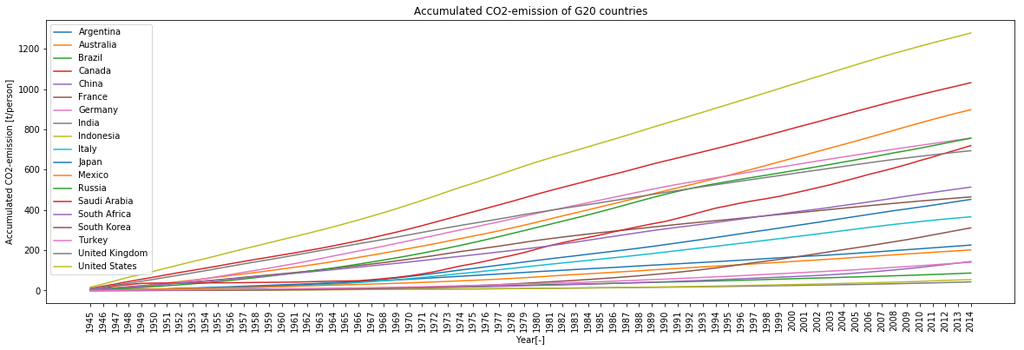

```python
df_co2_emissions_tonnes_per_person_transposed_g20_1945_2016_cum.plot()
plt.xticks(np.arange(len(df_co2_emissions_tonnes_per_person_transposed_g20_1945_2016_cum.index)),df_co2_emissions_tonnes_per_person_transposed_g20_1945_2016_cum.index, rotation='vertical')
plt.legend(loc='best')
plt.rcParams['figure.figsize'] = [20, 6]
plt.xlabel('Year[-]')
plt.ylabel('Accumulated CO2-emission [t/person]')
plt.title('Accumulated CO2-emission of G20 countries');
```

As you can see in the figure above, since 1970 a few G20 countries started to increase their CO2-emission quite rapidly. Consequently it would be interessting to investigate the %-increase of the CO2-emission per person since 1970.

```python
increase_emission_1970_2014=df_co2_emissions_tonnes_per_person_transposed_g20_1945_2016_cum.loc[['2014']].divide(df_co2_emissions_tonnes_per_person_transposed_g20_1945_2016_cum.loc[['1970']].values,axis='index')
```

```python
increase_emission_1970_2014=increase_emission_1970_2014.transpose()
```

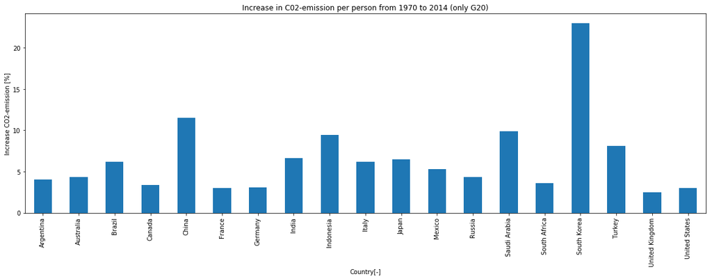

```python
increase_emission_1970_2014.plot.bar(legend=False)
plt.xlabel('Country[-]')
plt.ylabel('Increase CO2-emission [%]')
plt.title('Increase in C02-emission per person from 1970 to 2014 (only G20)');
```

The figure above shows that since 1970 the increase in CO2 emission in industrialized countries has not increased as much as the CO2 emissions in emerging markets like Indonesia, China, Turkey and South Korea. Further Question could be :

- how much of the total CO2-emission has been gained since 1970?
- is there a sign of a general slow down in CO2-emission in the past 5 years?

## Is there a correlation between population growth and C02-emission growth?

To answer this question the function corrwith() is used, which calculates the correlation between two DataFrames, matching column- and index names. Axis='columns' is chosen to get the correlation for each country, and not for each year

```python
corr_population_co2=df_population_total.corrwith(df_co2_emissions_yearly_1000_tonnes,axis='columns')
```

```python
corr_population_co2.head()
```

```
country
Afghanistan    0.716892
Albania        0.747953
Algeria        0.982125
Andorra        0.675679
Angola         0.939946
dtype: float64
```

```python
corr_population_co2.describe()
```

```
count    192.000000
mean       0.810263
std        0.310557
min       -0.873778
25%        0.826429
50%        0.908780
75%        0.960503
max        0.992441
dtype: float64
```

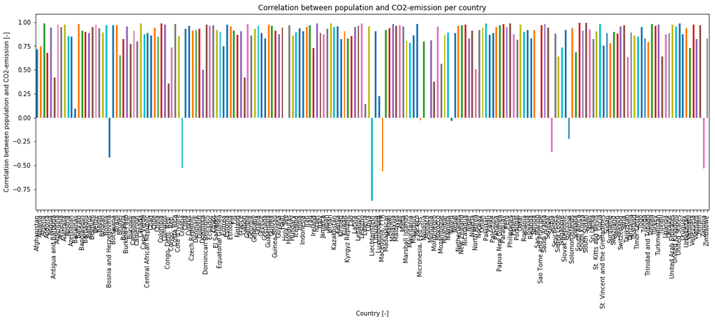

```python
corr_population_co2.plot.bar()
plt.xlabel('Country [-]')
plt.ylabel('Correlation between population and CO2-emission [-]')
plt.title('Correlation between population and CO2-emission per country');
```

The figure above shows that there is a strong correlation between CO2-emissions and the population. Since there are to many countries to display it accordingly, the selection got reduced to the G20 countries in the next step.

```python
corr_population_co2.loc[['Argentina', 'Australia', 'Brazil', 'Canada', 'China', 'France', 'Germany', 'India', 'Indonesia', 'Italy', 'Japan', 'Mexico', 'Russia', 'Saudi Arabia', 'South Africa', 'South Korea', 'Turkey', 'United Kingdom', 'United States']]
```

```
country
Argentina         0.970582
Australia         0.971747
Brazil            0.966696
Canada            0.983935
China             0.844050
France            0.903681
Germany           0.928160
India             0.934333
Indonesia         0.904584
Italy             0.886800
Japan             0.927821
Mexico            0.981480
Russia            0.915511
Saudi Arabia      0.980908
South Africa      0.992441
South Korea       0.909437
Turkey            0.960107
United Kingdom    0.954727
United States     0.984852
dtype: float64
```

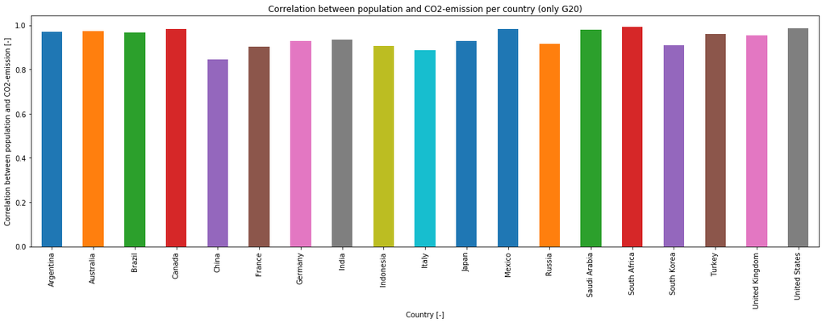

```python
corr_population_co2.loc[['Argentina', 'Australia', 'Brazil', 'Canada', 'China', 'France', 'Germany', 'India', 'Indonesia', 'Italy', 'Japan', 'Mexico', 'Russia', 'Saudi Arabia', 'South Africa', 'South Korea', 'Turkey', 'United Kingdom', 'United States']].plot.bar()
plt.xlabel('Country [-]')
plt.ylabel('Correlation between population and CO2-emission [-]')
plt.title('Correlation between population and CO2-emission per country (only G20)');
```

The figure clarifies that there is a strong positiv correlation between the population and the CO2 emission.

## Is there a correlation between higher gas prices and lower C02 emission?

To investiagte this question, first of all i calculated the correlation between the gas price and the CO2 emission per person using pandas .corrwith() function

```python
corr_gas_co2=df_pump_price_for_gasoline_us_per_liter.corrwith(df_co2_emissions_tonnes_per_person,axis='columns')
```

```python
corr_gas_co2.head()
```

```
country
Afghanistan    0.916700
Albania        0.836821
Algeria        0.297019
Andorra       -0.857762
Angola         0.834981
dtype: float64
```

To investigate further i want to take a closer look at the correlation between gas-price and C02 emissions in the G20-countries.

```python
corr_gas_co2.loc[['Argentina', 'Australia', 'Brazil', 'Canada', 'China', 'France', 'Germany', 'India', 'Indonesia', 'Italy', 'Japan', 'Mexico', 'Russia', 'Saudi Arabia', 'South Africa', 'South Korea', 'Turkey', 'United Kingdom', 'United States']]
```

```
country
Argentina         0.541611
Australia        -0.319898
Brazil            0.753552
Canada           -0.607442
China             0.979548
France           -0.749518
Germany          -0.880111
India             0.893879
Indonesia         0.539365
Italy            -0.813006
Japan            -0.036688
Mexico            0.483816
Russia            0.950660
Saudi Arabia     -0.163592
South Africa      0.602787
South Korea       0.882283
Turkey            0.915825
United Kingdom   -0.828806
United States    -0.845723
dtype: float64
```

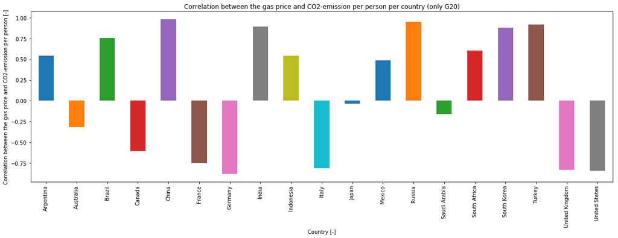

```python
corr_gas_co2.loc[['Argentina', 'Australia', 'Brazil', 'Canada', 'China', 'France', 'Germany', 'India', 'Indonesia', 'Italy', 'Japan', 'Mexico', 'Russia', 'Saudi Arabia', 'South Africa', 'South Korea', 'Turkey', 'United Kingdom', 'United States']].plot.bar()
plt.xlabel('Country [-]')
plt.ylabel('Correlation between the gas price and CO2-emission per person [-]')
plt.title('Correlation between the gas price and CO2-emission per person per country (only G20)');
```

Since the correlations are positive and negative there can not be given a clear answer. To investigate further there should be taken a look at possible other variables. Another reason for the inconsistently result could be, that the available data for the gas price is deficient. Based on the data that was available and investigated there can not be drawn the conclusion that a higher gas prices correlates with a lower CO2-emission.